# DNA Profile 2013

DSPG Business Innovation Team

7/9/2019

## 1. Read Data

Set year filter here.

```r
year <- 2013
path <- sprintf("./data/working/DNA_Aggregated/dna_%s.RDS", year)
dna.dt <- read_rds(path) %>%
  as.data.table()
```

This is the profiling for the year 2013.

## 2. Profile

Tidying the data.

```r
#Unlist columns
dna.dt <- dna.dt %>%
  dt_mutate(
    subject_codes = subject_codes %>% map_chr(.x = ., ~paste0(.x, collapse = ", "))
  )
```

General description.

```r
#Dimension
dna.dt %>%
  introduce()
```

```
##      rows columns discrete_columns continuous_columns all_missing_columns
## 1: 364203      33               33                  0                   0
##    total_missing_values complete_rows total_observations memory_usage
## 1:                14824        351834           12018699   1664118216
```

```r
#Tidy for head screenshot
dna.dt <- dna.dt %>%
  dplyr::select(c(an, title, body, publisher_name,
                  company_codes, subject_codes, everything()))
```

Names of variables.

```r
#Variable Names
names(dna.dt) %>% paste0(., collapse = ", ")
```

```
## [1] "an, title, body, publisher_name, company_codes, subject_codes, copyright, art, modification_datetime, company_codes_occur, company_codes_about, company_codes_lineage, snippet, publication_date, market_index_codes, credit, currency_codes, region_of_origin, ingestion_datetime, modification_dat…
```

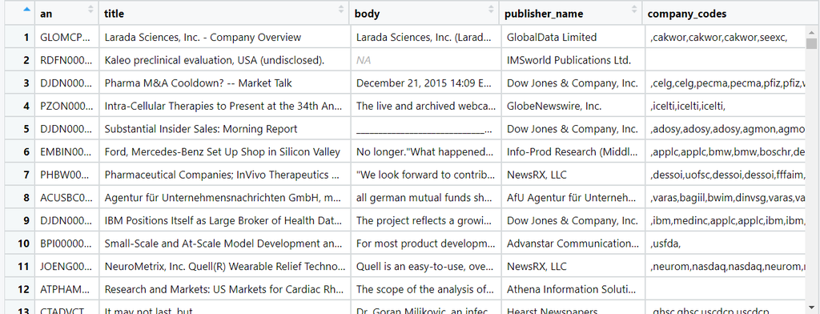

```r
plot_str(dna.dt)
```

[output not shown]

```r
#Structure of Data
str(dna.dt)
```

```
## Classes 'data.table' and 'data.frame':   364203 obs. of  33 variables:
##  $ an                       : chr  "PBRELS0020140117e9cn00004" "DJDN000020130802e98200408" "INDFED0020130221e92l0002l" "DJDN000020130227e92r006t1" ...
##  $ title                    : chr  "FibroGen initiates patient enrolment in Phase II trial of FG-3019 to treat IPF patients." "DJ CHART Gilead Sciences ST: the upside prevails as long as 59.5 is support" "US Patent Issued to ZymoGenetics on Feb. 19 for \"Methods of Antagonizing Signal Transductio…
##  $ body                     : chr  "PBR Pharmaceutical Business Review\n\nWebsite: http://www.pharmaceutical-business-review.com/" "59.5 is our pivot point.\n\nOur preference: the upside prevails as long as 59.5 is support.\n\nAlternative scen"| __truncated__ "According to the abstract released b…
##  $ publisher_name           : chr  "Elsevier Science Ltd." "Dow Jones & Company, Inc." "HT Media Limited" "Dow Jones & Company, Inc." ...
##  $ company_codes            : chr  "" ",gilsci,gilsci,gilsci," ",zymtic,uspto,zymtic,brstmy," ",brstmy,brstmy," ...
##  $ subject_codes            : chr  "c23, ctrial, nabst, c22, ccat, ncat, nfact, nfcpin" "c1521, ccat, neqac, c15, c152, ncat, nfact, nfce, nfcpin" "c133, c13, ccat, cgymtr, cinprp, ncat, nfact, nfcpin" "c02, c182, cdirdl, cissal, c17, c171, c18, c41, cactio, ccat, ncat, nfact, nfcpex, nfcpin" ...
##  $ copyright                : chr  "© 2013 Elsevier Engineering Information   " "Copyright © 2013, Dow Jones & Company, Inc.  " "Copyright 2013. HT Media Limited. All rights reserved.   " "Copyright (c) 2013, Dow Jones & Company, Inc.   " ...
##  $ art                      : chr  "" "" "" "" ...
##  $ modification_datetime    : chr  "1389949456000" "1390297278000" "1361430320000" "1361999537000" ...
##  $ company_codes_occur      : chr  "" ",gilsci," ",zymtic,uspto," ",brstmy," ...
##  $ company_codes_about      : chr  "" ",gilsci," ",zymtic," ",brstmy," ...
##  $ company_codes_lineage    : chr  "" "" ",brstmy," "" ...
##  $ snippet                  : chr  "Enrolment of patients with idiopathic pulmonary fibrosis (IPF) was initiated by FibroGen in a Phase II clinical"| __truncated__ "\n \n   (TRADING Central) PARIS -- Click here to see our chart: \n\nhttp://www.tradingcentral.com/chart/GILDUSD"| __truncated__ "ALE…
##  $ publication_date         : chr  "1387756800000" "1375455268077" "1361404800000" "1361999471377" ...
```

[output cut: 20 more lines]

```r
#Percent Missing by Variable
percent.missing <- dna.dt %>%
  is.na.data.frame() %>%
  apply(., 2, mean) %>%
  round(3)
percent.missing
```

```
##                        an                     title
##                     0.000                     0.000
##                      body            publisher_name
##                     0.023                     0.000
##             company_codes             subject_codes
##                     0.000                     0.000
##                 copyright                       art
##                     0.000                     0.000
##     modification_datetime       company_codes_occur
##                     0.000                     0.000
##       company_codes_about     company_codes_lineage
##                     0.000                     0.000
##                   snippet          publication_date
##                     0.017                     0.000
##        market_index_codes                    credit
##                     0.000                     0.000
##            currency_codes          region_of_origin
##                     0.000                     0.001
##        ingestion_datetime         modification_date
##                     0.000                     0.000
##               source_name             language_code
##                     0.000                     0.000
##              region_codes company_codes_association
##                     0.000                     0.000
##              person_codes                    byline
##                     0.000                     0.000
##   company_codes_relevance               source_code
##                     0.000                     0.000
##                word_count            industry_codes
##                     0.000                     0.000
##      publication_datetime                    action
##                     0.000                     0.000
##             document_type
##                     0.000
```

```r
#plot_bar(dna.dt$action)
```

# 3. Preliminary Cleaning

#### Word Count (Body of Text)

Here, we filter out articles with body text less than 10 words in length, as this indicates is not a “true” article in the scope of our interest. For plotting, we trimmed at 5000 length word. The new data is renamed so the original is still available for later use.

```r
#Cleaning out WC
dna.2.dt <- dna.dt %>%
  dt_mutate(
    word_count = word_count %>% as.numeric()
  ) %>%
  dt_filter(word_count > 10 & word_count < 2000)

#Summary
summary(dna.2.dt$word_count)
```

```
##    Min. 1st Qu.  Median    Mean 3rd Qu.    Max.
##    11.0   204.0   349.0   468.4   572.0  1999.0
```

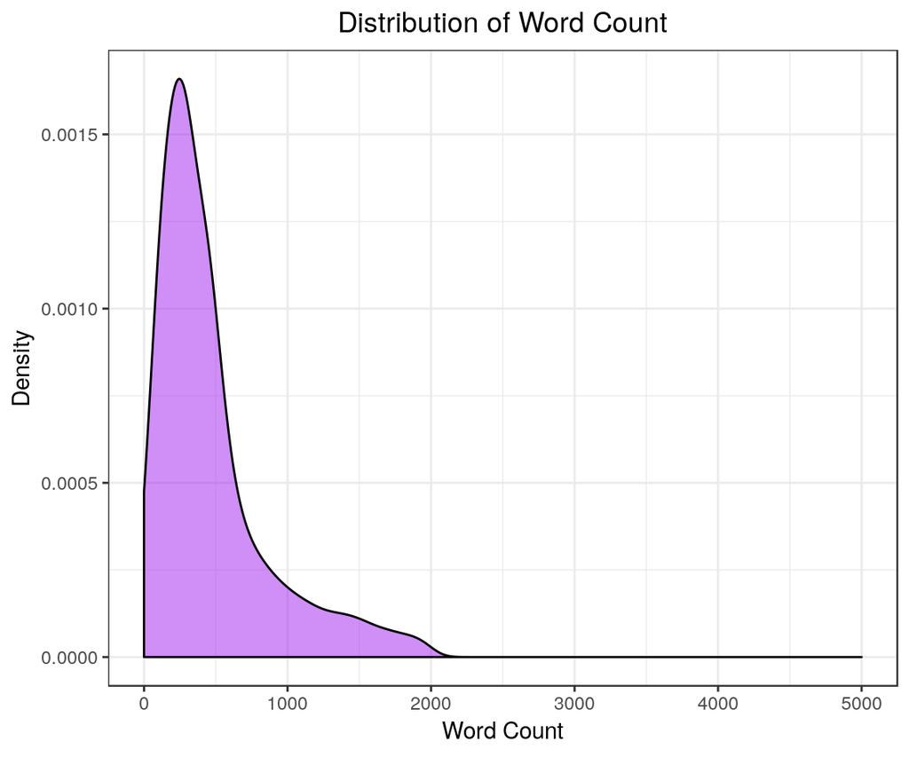

```r
#Distribution
ggplot(dna.2.dt, aes(x = word_count)) +
  geom_density(fill = "purple", alpha = 0.5, adjust = 4, trim = FALSE) +
  labs(
    x = "Word Count",
    y = "Density",
    title = "Distribution of Word Count"
  ) +
  xlim(0, 5000)
```

#### Sources (of Publishers)

```r
#Data frame for all combos of unique codes, names
asd <- dna.2.dt[, list(source_code, source_name, publisher_name)] %>% unique()

#Unique source codes
dna.2.dt$source_code %>% unique() %>% length()
```

```
## [1] 1593
```

```r
#" " names
dna.2.dt$source_name %>% unique() %>% length()
```

```
## [1] 1614
```

```r
#Unique publisher names
dna.2.dt$publisher_name %>% unique() %>% length()
```

```
## [1] 592
```

```r
#Joining for unique data frame (writen out)
asd <- left_join(asd, dna.2.dt[, list(source_code, source_name, publisher_name)] %>%
                   group_by(source_code) %>%
                   summarise(
                     count_source_code = n()
                   ), by = "source_code")

asd <- left_join(
  asd, dna.2.dt[, list(source_code, source_name, publisher_name)] %>%
    group_by(source_name) %>%
    summarise(
      count_source_name = n()
    ), by = "source_name"
)

asd <- left_join(
  asd, dna.2.dt[, list(source_code, source_name, publisher_name)] %>%
    group_by(publisher_name) %>%
    summarise(
      count_publisher_name = n()
    ), by = "publisher_name"
)

#write_csv(unique(asd), "./data/working/DNA_Aggregated/unique_publisher_sources.csv")

#Top 10 Unique Names
dna.2.dt %>%
  group_by(publisher_name) %>%
  summarise(
    Count = n()
  ) %>%
  arrange(desc(Count)) %>%
  dt_mutate(
    publisher_name = publisher_name %>%
      as.factor() %>%
      forcats::fct_reorder(., Count)
  ) %>%
  slice(1:10)
```

```
##                            publisher_name  Count
## 1                              NewsRx.com 123316
## 2               Dow Jones & Company, Inc.  73386
## 3                        HT Media Limited  19896
## 4                    Close-Up Media, Inc.  18604
## 5                   Elsevier Science Ltd.  10494
## 6                     Theflyonthewall.com   8112
## 7  Athena Information Solutions Pvt. Ltd.   7884
## 8                 Press Association, Inc.   5106
## 9                       Normans Media Ltd   4906
## 10                    Business Wire, Inc.   4762
```

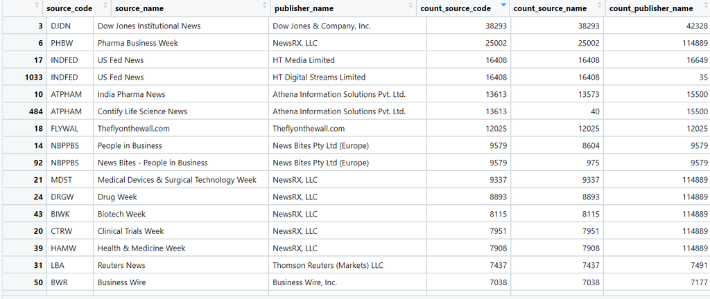

#### Company Names

Look at unique company names and the top 10 mentioned in these articles for 2013 (in combination with others).

```r
#Str_split to get list of char vectors of region
dna.2.dt <- dna.2.dt %>%
  dt_mutate(
    company_codes = str_split(company_codes, ",") %>%
      lapply(., function(x) {x[c(-1, -length(x))]})    #storing subj codes as nested list of char vector
  )

#Unique
dna.2.dt$company_codes %>%
  unlist() %>%
  unique() %>%
  length()
```

```
## [1] 26981
```

```r
#Summary
company.counts <- dna.2.dt$company_codes %>% map_dbl(.x = ., ~length(.x))
company.counts %>% summary()
```

```
##    Min. 1st Qu.  Median    Mean 3rd Qu.    Max.
##   0.000   2.000   4.000   5.612   6.000 286.000
```

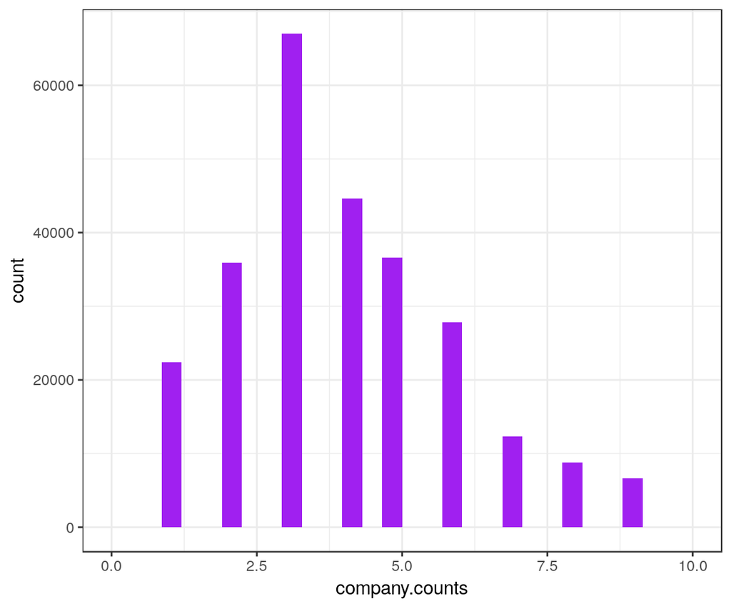

```r
#Histogram
tibble(company.counts = company.counts) %>%
  ggplot(aes(x = company.counts)) +
  geom_histogram(fill = "purple") +
  # geom_density(fill = "purple", adjust = 5) +
  xlim(0, 10)
```

```r
#Top 10
data.table(company = dna.2.dt$company_codes %>%
             unlist() %>%
             table() %>%
             names(),
           counts = dna.2.dt$company_codes %>%
             unlist() %>%
             table() %>%
             as.numeric()) %>%
  dt_arrange(counts) %>%
  Rev(margin = 1) %>%
  slice(1:10)
```

```
##    company counts
## 1    seexc  81129
## 2    usfda  42816
## 3     pfiz  20407
## 4   fffaim  19424
## 5   jonjon  14950
## 6     glxo  11739
## 7   brstmy  11294
## 8     amge  11215
## 9    lilye  10335
## 10  medinc   9799
```

#### Company Names (About)

Look at unique company names (about) and the top 10 mentioned in these articles for 2013 (in combination with others).

```r
#Str_split to get list of char vectors of region
dna.2.dt <- dna.2.dt %>%
  dt_mutate(
    company_codes_about = str_split(company_codes_about, ",") %>%
      lapply(., function(x) {x[c(-1, -length(x))]})    #storing subj codes as nested list of char vector
  )

#Unique
dna.2.dt$company_codes_about %>%
  unlist() %>%
  unique() %>%
  length()
```

```
## [1] 14435
```

```r
#Summary
company.counts <- dna.2.dt$company_codes_about %>% map_dbl(.x = ., ~length(.x))
company.counts %>% summary()
```

```
##    Min. 1st Qu.  Median    Mean 3rd Qu.    Max.
##    0.00    1.00    1.00    1.31    1.00  110.00
```

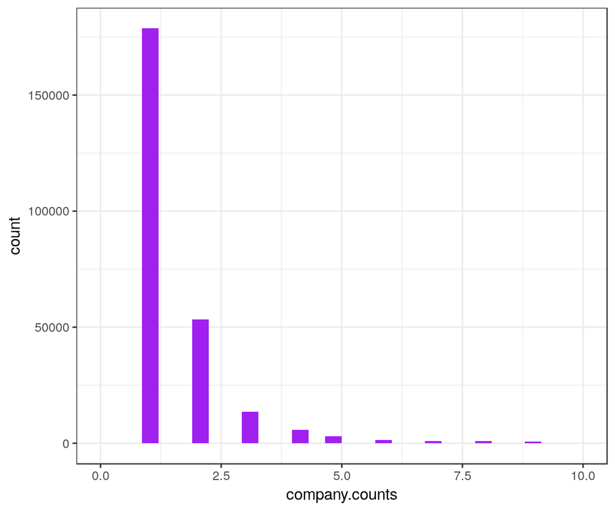

```r
#Histogram
tibble(company.counts = company.counts) %>%
  ggplot(aes(x = company.counts)) +
  geom_histogram(fill = "purple") +
  # geom_density(fill = "purple", adjust = 5) +
  xlim(0, 10)
```

```r
#Top 10
data.table(company = dna.2.dt$company_codes_about %>%
             unlist() %>%
             table() %>%
             names(),
           counts = dna.2.dt$company_codes_about %>%
             unlist() %>%
             table() %>%
             as.numeric()) %>%
  dt_arrange(counts) %>%
  Rev(margin = 1) %>%
  slice(1:10)
```

```
##    company counts
## 1    usfda  12747
## 2    seexc   8343
## 3     pfiz   5720
## 4   jonjon   4190
## 5   schplo   3754
## 6     glxo   3458
## 7   brstmy   3417
## 8   medinc   3378
## 9    lilye   3275
## 10    amge   3008
```

```r
#Notes

#- Articles w/ no company codes
#- Count how many only fda, sec, and nasdaq (locate, filter)
#- Subject_code, new_product (investigate?) ns? C22 new product? CDNN innovation, cgvfil gov files?
#- Filtering by keywords "in the text body" / subject code?
#- iterate "for all years"
```

#### Articles With No Company Code?

```r
#Company Codes About
map_lgl(.x = company.about$company_codes_about, is_empty) %>% sum()
map_lgl(company.about$company_codes_about, is_empty) %>% mean()

#Company Codes
map_lgl(.x = company$company_codes, is_empty) %>% sum()
map_lgl(company$company_codes, is_empty) %>% mean()

#Both
map2_lgl(.x = company$company_codes, .y = company.about$company_codes_about, ~is_empty(.x) & is_empty(.y)) %>%
  sum()
map2_lgl(.x = company$company_codes, .y = company.about$company_codes_about, ~is_empty(.x) & is_empty(.y)) %>%
  mean() %>%
  round(4)

#Either
map2_lgl(.x = company$company_codes, .y = company.about$company_codes_about, ~is_empty(.x) | is_empty(.y)) %>%
  sum()
map2_lgl(.x = company$company_codes, .y = company.about$company_codes_about, ~is_empty(.x) | is_empty(.y)) %>%
  mean() %>%
  round(4)
```

[output not shown]

The data suggest that 74958 “Company Codes About” are missing, or roughly 0.2231 proportion of the data; while for companies 40009 are empty, comprising roughly 0.1191 of these data. Considering the overlap between these two missing values, 40009 are missing both company and company about; comprising roughly 0.1191 proportion of the data. Lastly, 74958 are missing either value, comprising 0.2231 proportion of the data from 2013.

#### Locate and Filter Company (FDA, SEC, NASDAQ)

```r
#Filtered df by company != FDA, SEC, or NASDAQ
dna.3.dt <- dna.2.dt %>%
  dt_mutate(
 #   company_codes = str_split(company_codes, ",") %>%
#      lapply(., function(x) {x[c(-1, -length(x))]}),    #storing subj codes as nested list of char vector
#    company_codes_about = str_split(company_codes_about, ",") %>%
#      lapply(., function(x) {x[c(-1, -length(x))]}),    #storing subj codes as nested list of char vector
    filter_company = ifelse(map_lgl(.x = company_codes, ~length(.x) != 1),
                            FALSE,
                            map_lgl(.x = company_codes, ~str_detect(.x, "usfda|seexc|nasdaq") %>% any(isTRUE(.)))),
    filter_company_about = ifelse(map_lgl(.x = company_codes_about, ~length(.x) != 1),
                                  FALSE,
                                  map_lgl(.x = company_codes_about, ~str_detect(.x, "usfda|seexc|nasdaq") %>% any(isTRUE(.))))
  )

#Count how many have only fda, sec, nasdaq in company, company about, or either.
dna.3.dt$filter_company %>% sum()
```

```
## [1] 1402
```

```r
dna.3.dt$filter_company_about %>% sum()
```

```
## [1] 4683
```

```r
(dna.3.dt$filter_company | dna.3.dt$filter_company_about) %>% sum()
```

```
## [1] 5246
```

```r
#Filter out either variable
dna.3.dt <- dna.3.dt %>%
  dt_mutate(
    filter_either = dna.3.dt$filter_company | dna.3.dt$filter_company_about
  ) %>%
  dt_filter(filter_either != TRUE) %>%
  dt_select(-c(filter_company, filter_company_about, filter_either))
```

#### Industry Investigation

```r
#Number of Unique Industry codes
dna.3.dt <- dna.3.dt %>%
  dt_mutate(
    industry_codes_empty =  map(.x = industry_codes, ~ifelse(.x %in% "", character(0), .x)),
    industry_codes = str_split(industry_codes, ",") %>%
      lapply(., function(x) {x[c(-1, -length(x))]}),    #storing industry codes as nested list of char vector
    industry_codes = map(.x = industry_codes, ~ifelse(.x %in% "", character(0), .x))
  )

#Industry codes
#Pharmaceuticals
#Number of Empty INdustry Codes
map_lgl(.x = dna.3.dt$industry_codes_empty, ~is.na(.x)) %>% sum()
```

```
## [1] 0
```

```r
map_lgl(.x = dna.3.dt$industry_codes_empty, ~is.na(.x)) %>% mean()
```

```
## [1] 0
```

```r
#Most Common Industry Codes (10)
data.table(industry = dna.3.dt$industry_codes %>%
             unlist() %>%
             table() %>%
             names(),
           counts = dna.3.dt$industry_codes %>%
             unlist() %>%
             table() %>%
             as.numeric()) %>%
  dt_arrange(counts) %>%
  Rev(margin = 1) %>%
  slice(1:10)
```

```
##    industry counts
## 1      i951 279185
## 2      i257 244206
## 3      i372 119860
## 4   idrugty  87684
## 5     i2569  70845
## 6    iphmed  70371
## 7    ibioph  38881
## 8  itheradv  35358
## 9     itech  17625
## 10   ifinal  17265
```

```r
#Pharma
map_lgl(.x = dna.3.dt$industry_codes, ~c("i257") %in% .x) %>% sum()
```

```
## [1] 244206
```

```r
#Medical Equipment/Supplies
map_lgl(.x = dna.3.dt$industry_codes, ~c("i372") %in% .x ) %>% sum()
```

```
## [1] 119860
```

```r
#Remove FDA Source Codes (from publisher)
dna.3.dt <- dna.3.dt %>%
  dt_mutate(
    source_filter = str_detect(source_code, paste0(c("USFOD", "WCUSFOD", "FDADOC", "FDADB", "FDDB"), collapse = "|"))
  )

#Number of Publisher sources coming from FDA
dna.3.dt$source_filter %>% sum()
```

```
## [1] 1270
```

```r
#Filter and remove sourc_filter variable
dna.3.dt <- dna.3.dt %>%
  dt_filter(source_filter %in% FALSE) %>%
  dt_select(-source_filter)
```

#### Summary of Final (FDA & WC) Filtered Data

```r
#Dimension
dim(dna.3.dt)
```

```
## [1] 329535     34
```

```r
#Summary of final data
str(dna.3.dt)
```

[output not shown]

[output cut: 381 more lines]

[output not shown]